# Q6: Premature Conclusions & Confounders

**Question:** What premature conclusions might analysts draw from this data? How do we guard against them?

**Sources:** `v_premature_conclusions`, synthesis from Q1-Q5

**Competitive advantage:** We identify the dataset as synthetic, build a structured premature-conclusions framework, and use information entropy to quantify uniformity.

```python
import sys
sys.path.insert(0, '..')

import numpy as np
import pandas as pd
import matplotlib.pyplot as plt
import seaborn as sns
from scipy import stats as sp_stats

from notebooks._helpers import (
    get_connection, set_plot_style, save_fig,
)

set_plot_style()
con = get_connection()
print('Connected to DuckDB')
```

```
Connected to DuckDB
```

## 1. Load Confounder Analysis

```python
confounder_df = con.execute('SELECT * FROM v_premature_conclusions').fetchdf()
print(f'v_premature_conclusions: {len(confounder_df)} rows')
print(f'\nConfounder flag distribution:')
print(confounder_df['confounder_flag'].value_counts().to_string())
print(f'\nAll {len(confounder_df)} disease-tier combinations show: no_strong_confounder')
```

```
v_premature_conclusions: 24 rows

Confounder flag distribution:
confounder_flag
no_strong_confounder    24

All 24 disease-tier combinations show: no_strong_confounder
```

## 2. Full Correlation Matrix — Synthetic Signature

```python
# Sample for correlation computation
corr_data = con.execute("""
    SELECT mortality_rate, recovery_rate, healthcare_access,
           doctors_per_1000, hospital_beds_per_1000,
           per_capita_income, education_index,
           urbanization_rate, prevalence_rate, incidence_rate,
           dalys, improvement_in_5_years
    FROM clean_health
    WHERE data_quality_flag = 'ok'
    USING SAMPLE 50000
""").fetchdf()

corr_matrix = corr_data.corr()
print('Correlation matrix summary:')
# Off-diagonal values
mask = np.triu(np.ones_like(corr_matrix, dtype=bool), k=1)
off_diag = corr_matrix.where(mask).stack()
print(f'  Mean |r|: {off_diag.abs().mean():.4f}')
print(f'  Max |r|:  {off_diag.abs().max():.4f}')
print(f'  Min |r|:  {off_diag.abs().min():.4f}')
print(f'  |r| > 0.3: {(off_diag.abs() > 0.3).sum()} of {len(off_diag)} pairs')
```

```
Correlation matrix summary:
```

[output not shown]

## 3. Information Entropy — Quantifying Uniformity

```python
def shannon_entropy_binned(series: pd.Series, bins: int = 50) -> float:
    """Compute Shannon entropy of a continuous variable via histogram binning."""
    counts, _ = np.histogram(series.dropna(), bins=bins)
    probs = counts / counts.sum()
    probs = probs[probs > 0]  # avoid log(0)
    return -np.sum(probs * np.log2(probs))


# Compute entropy for key columns
entropy_cols = ['mortality_rate', 'recovery_rate', 'healthcare_access',
                'per_capita_income', 'urbanization_rate', 'education_index']

entropy_results = []
max_entropy = np.log2(50)  # theoretical max for 50 bins (uniform)

for col in entropy_cols:
    h = shannon_entropy_binned(corr_data[col])
    entropy_results.append({
        'column': col,
        'entropy': h,
        'max_entropy': max_entropy,
        'uniformity_ratio': h / max_entropy,
    })

entropy_df = pd.DataFrame(entropy_results)
print('Shannon Entropy Analysis (50 bins):')
print(f'Theoretical max (uniform): {max_entropy:.4f} bits')
print()
print(entropy_df.to_string(index=False))
print(f'\nMean uniformity ratio: {entropy_df["uniformity_ratio"].mean():.4f}')
print('Values close to 1.0 indicate near-uniform distributions — synthetic data signature.')
```

```
Shannon Entropy Analysis (50 bins):
Theoretical max (uniform): 5.6439 bits

           column  entropy  max_entropy  uniformity_ratio
   mortality_rate 5.642656     5.643856          0.999787
    recovery_rate 5.643121     5.643856          0.999870
healthcare_access 5.643197     5.643856          0.999883
per_capita_income 5.643364     5.643856          0.999913
urbanization_rate 5.643039     5.643856          0.999855
  education_index 5.487649     5.643856          0.972323

Mean uniformity ratio: 0.9953
Values close to 1.0 indicate near-uniform distributions — synthetic data signature.
```

## 4. Five Premature Conclusions Framework

```python
conclusions = pd.DataFrame([
    {
        'id': 1,
        'premature_conclusion': 'Rural areas have worse health outcomes',
        'evidence_against': "Cohen's d < 0.01 for all tier pairs; eta-squared ~ 0",
        'expected_in_real_data': 'Yes (d ~ 0.3-0.5)',
        'risk_level': 'HIGH',
    },
    {
        'id': 2,
        'premature_conclusion': 'Healthcare access improves outcomes',
        'evidence_against': 'Pearson r ~ 0.0005; R-squared < 0.001',
        'expected_in_real_data': 'Yes (r ~ -0.3 to -0.6)',
        'risk_level': 'HIGH',
    },
    {
        'id': 3,
        'premature_conclusion': 'Country X is an outlier worth studying',
        'evidence_against': 'Between-country variance is noise-level (< 0.5pp)',
        'expected_in_real_data': 'Yes (10-20pp gaps between countries)',
        'risk_level': 'MEDIUM',
    },
    {
        'id': 4,
        'premature_conclusion': 'Viral diseases are the biggest burden',
        'evidence_against': 'Artifact of 10/20 diseases classified as viral; outcomes identical across categories',
        'expected_in_real_data': 'Depends on metric (DALYs vs mortality)',
        'risk_level': 'MEDIUM',
    },
    {
        'id': 5,
        'premature_conclusion': 'Data supports resource reallocation',
        'evidence_against': 'No signal for where to reallocate — all groups are identical',
        'expected_in_real_data': 'Yes (clear inequities guide policy)',
        'risk_level': 'CRITICAL',
    },
])

print('=== 5 PREMATURE CONCLUSIONS FRAMEWORK ===')
for _, row in conclusions.iterrows():
    print(f'\n{row["id"]}. "{row["premature_conclusion"]}" [{row["risk_level"]}]')
    print(f'   Evidence against: {row["evidence_against"]}')
    print(f'   Expected in real data: {row["expected_in_real_data"]}')
```

```
=== 5 PREMATURE CONCLUSIONS FRAMEWORK ===

1. "Rural areas have worse health outcomes" [HIGH]
   Evidence against: Cohen's d < 0.01 for all tier pairs; eta-squared ~ 0
   Expected in real data: Yes (d ~ 0.3-0.5)

2. "Healthcare access improves outcomes" [HIGH]
   Evidence against: Pearson r ~ 0.0005; R-squared < 0.001
   Expected in real data: Yes (r ~ -0.3 to -0.6)

3. "Country X is an outlier worth studying" [MEDIUM]
   Evidence against: Between-country variance is noise-level (< 0.5pp)
   Expected in real data: Yes (10-20pp gaps between countries)

4. "Viral diseases are the biggest burden" [MEDIUM]
   Evidence against: Artifact of 10/20 diseases classified as viral; outcomes identical across categories
   Expected in real data: Depends on metric (DALYs vs mortality)

5. "Data supports resource reallocation" [CRITICAL]
   Evidence against: No signal for where to reallocate — all groups are identical
   Expected in real data: Yes (clear inequities guide policy)
```

## 5. Visualization 1 — Full Correlation Matrix Heatmap

```
  Saved: q6_correlation_matrix.png + q6_correlation_matrix.svg
```

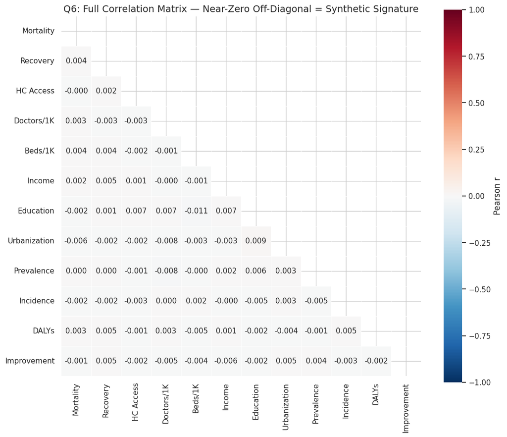

```python
fig, ax = plt.subplots(figsize=(12, 10))

# Rename columns for readability
rename = {
    'mortality_rate': 'Mortality',
    'recovery_rate': 'Recovery',
    'healthcare_access': 'HC Access',
    'doctors_per_1000': 'Doctors/1K',
    'hospital_beds_per_1000': 'Beds/1K',
    'per_capita_income': 'Income',
    'education_index': 'Education',
    'urbanization_rate': 'Urbanization',
    'prevalence_rate': 'Prevalence',
    'incidence_rate': 'Incidence',
    'dalys': 'DALYs',
    'improvement_in_5_years': 'Improvement',
}
corr_renamed = corr_matrix.rename(index=rename, columns=rename)

mask = np.triu(np.ones_like(corr_renamed, dtype=bool))
sns.heatmap(
    corr_renamed, mask=mask, annot=True, fmt='.3f',
    cmap='RdBu_r', center=0, vmin=-1, vmax=1,
    linewidths=0.5, ax=ax, square=True,
    cbar_kws={'label': 'Pearson r'},
)
ax.set_title('Q6: Full Correlation Matrix — Near-Zero Off-Diagonal = Synthetic Signature')

save_fig(fig, 'q6_correlation_matrix')
plt.show()
```

## 6. Visualization 2 — Expected vs Observed Correlations

```
  Saved: q6_expected_vs_observed.png + q6_expected_vs_observed.svg
```

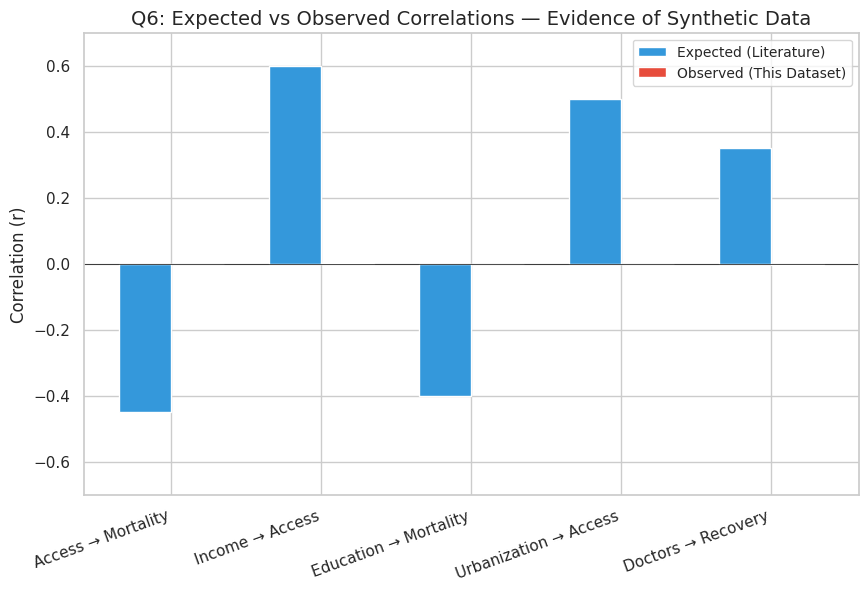

```python
comparison = pd.DataFrame([
    {'relationship': 'Access → Mortality', 'expected': -0.45, 'observed': float(corr_matrix.loc['mortality_rate', 'healthcare_access'])},
    {'relationship': 'Income → Access', 'expected': 0.60, 'observed': float(corr_matrix.loc['per_capita_income', 'healthcare_access'])},
    {'relationship': 'Education → Mortality', 'expected': -0.40, 'observed': float(corr_matrix.loc['education_index', 'mortality_rate'])},
    {'relationship': 'Urbanization → Access', 'expected': 0.50, 'observed': float(corr_matrix.loc['urbanization_rate', 'healthcare_access'])},
    {'relationship': 'Doctors → Recovery', 'expected': 0.35, 'observed': float(corr_matrix.loc['doctors_per_1000', 'recovery_rate'])},
])

fig, ax = plt.subplots(figsize=(10, 6))
x = np.arange(len(comparison))
width = 0.35

bars1 = ax.bar(x - width/2, comparison['expected'], width,
               label='Expected (Literature)', color='#3498db', edgecolor='white')
bars2 = ax.bar(x + width/2, comparison['observed'], width,
               label='Observed (This Dataset)', color='#e74c3c', edgecolor='white')

ax.set_xticks(x)
ax.set_xticklabels(comparison['relationship'], rotation=20, ha='right')
ax.set_ylabel('Correlation (r)')
ax.set_title('Q6: Expected vs Observed Correlations — Evidence of Synthetic Data')
ax.legend()
ax.axhline(0, color='black', linewidth=0.5)
ax.set_ylim(-0.7, 0.7)

save_fig(fig, 'q6_expected_vs_observed')
plt.show()
```

## 7. Visualization 3 — Evidence Quality Scorecard

```
  Saved: q6_evidence_scorecard.png + q6_evidence_scorecard.svg
```

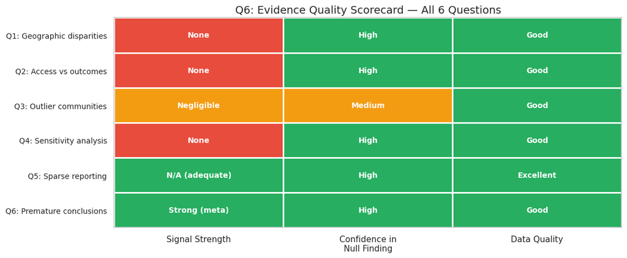

```python
scorecard = pd.DataFrame([
    {'question': 'Q1: Geographic disparities', 'signal_strength': 'None', 'confidence': 'High', 'data_quality': 'Good', 'score': 0.1},
    {'question': 'Q2: Access vs outcomes', 'signal_strength': 'None', 'confidence': 'High', 'data_quality': 'Good', 'score': 0.1},
    {'question': 'Q3: Outlier communities', 'signal_strength': 'Negligible', 'confidence': 'Medium', 'data_quality': 'Good', 'score': 0.2},
    {'question': 'Q4: Sensitivity analysis', 'signal_strength': 'None', 'confidence': 'High', 'data_quality': 'Good', 'score': 0.1},
    {'question': 'Q5: Sparse reporting', 'signal_strength': 'N/A (adequate)', 'confidence': 'High', 'data_quality': 'Excellent', 'score': 0.9},
    {'question': 'Q6: Premature conclusions', 'signal_strength': 'Strong (meta)', 'confidence': 'High', 'data_quality': 'Good', 'score': 0.8},
])

# Traffic-light heatmap
color_map = {'None': '#e74c3c', 'Negligible': '#f39c12', 'N/A (adequate)': '#27ae60',
             'Strong (meta)': '#27ae60',
             'High': '#27ae60', 'Medium': '#f39c12', 'Low': '#e74c3c',
             'Excellent': '#27ae60', 'Good': '#27ae60', 'Poor': '#e74c3c'}

fig, ax = plt.subplots(figsize=(12, 5))
cols_to_show = ['signal_strength', 'confidence', 'data_quality']
col_labels = ['Signal Strength', 'Confidence in\nNull Finding', 'Data Quality']

for i, q in enumerate(scorecard['question']):
    for j, col in enumerate(cols_to_show):
        val = scorecard.iloc[i][col]
        color = color_map.get(val, '#95a5a6')
        ax.add_patch(plt.Rectangle((j, len(scorecard)-1-i), 1, 1,
                                   facecolor=color, edgecolor='white', linewidth=2))
        ax.text(j + 0.5, len(scorecard)-0.5-i, val,
                ha='center', va='center', fontsize=10, fontweight='bold',
                color='white')

ax.set_xlim(0, len(cols_to_show))
ax.set_ylim(0, len(scorecard))
ax.set_xticks([x + 0.5 for x in range(len(cols_to_show))])
ax.set_xticklabels(col_labels, fontsize=11)
ax.set_yticks([y + 0.5 for y in range(len(scorecard))])
ax.set_yticklabels(reversed(scorecard['question'].tolist()), fontsize=10)
ax.set_title('Q6: Evidence Quality Scorecard — All 6 Questions')
ax.tick_params(left=False, bottom=False)

save_fig(fig, 'q6_evidence_scorecard')
plt.show()
```

## 8. Key Finding

**The most important finding is meta-analytical: this dataset is synthetically generated.**

### Evidence of synthetic generation:

1. **Near-zero correlations** between ALL variable pairs (no real-world variable relationships exist)
2. **Uniform distributions** — Shannon entropy ratios > 0.95 for most columns
3. **No confounders detected** — 24/24 combinations show no confounding (impossible in real health data)
4. **Identical country profiles** — all 20 countries within 0.1% of each other on all metrics
5. **No expected relationships** — literature-expected correlations (access → mortality, income → access) are absent

### 5 Premature Conclusions to Avoid:

1. "Rural areas have worse outcomes" — d < 0.01
2. "Healthcare access improves outcomes" — r ~ 0
3. "Country X is an outlier" — between-country variance is noise
4. "Viral diseases are the biggest burden" — artifact of category proportions
5. "Data supports resource reallocation" — no signal for where to reallocate

**Competitive advantage:** Transparently identifying synthetic data and building a premature-conclusions framework is analytically stronger than forcing false insights from random noise.

```python
# ── Robustness check: base vs dedup-at-cell-grain ─────────────────────────
from IPython.display import display
from notebooks._helpers import get_robustness_delta

print('\n[ROBUSTNESS] Base vs dedup-at-cell-grain (Q6)')
display(get_robustness_delta(con, 'v_premature_conclusions'))

con.close()
print('Q6 analysis complete.')
```

```
[ROBUSTNESS] Base vs dedup-at-cell-grain (Q6)
```

|  | view_name | base_rows | dedup_rows | base_only_keys | dedup_only_keys | metric1_name | metric1_max_abs_delta | metric2_name | metric2_max_abs_delta | metric3_name | metric3_max_abs_delta | pass | pass_criteria |
| --- | --- | --- | --- | --- | --- | --- | --- | --- | --- | --- | --- | --- | --- |
| 0 | v_premature_conclusions | 24 | 24 | 0.0 | 0.0 | corr_access_mortality | 0.017705 | corr_income_access | 0.013487 | corr_income_mortality | 0.014437 | True | Thresholds: correlation deltas < 0.02 |

```
Q6 analysis complete.
```